# Exploring the Day 1 Survey

Thomas E. Love

2018-09-05

```r
knitr::opts_chunk$set(comment=NA)
options(width = 70)
```

# Load the R Packages we need

```r
library(magrittr); library(tidyverse)
## always need tidyverse, can include other packages too
```

# Load the Data

We will read in the .csv file of the data, and then pipe that result into the `tbl_df` function, which turns the data frame into a nicely organized *tibble*.

- Since we’ve carefully stored the data file in the same directory as our R Project, we can read it in directly.

```r
day1 <- read.csv("surveyday1_2018.csv") %>% tbl_df
```

# Key Verbs in the Tidyverse for Data Wrangling

## Print your tibble by typing its name

```r
day1
```

```
# A tibble: 254 x 20
   student sex   english statsofar ageguess smoke h.left h.right
     <int> <fct> <fct>       <int>    <int> <int>  <int>   <int>
 1  201801 m     n               5       45     1      9      11
 2  201802 f     y               6       50     1      0      10
 3  201803 f     y               7       45     1      0      10
 4  201804 f     y               6       50     1      0      10
 5  201805 f     n               5       46     1      2      18
 6  201806 f     y               5       48     1      0      20
 7  201807 f     y               6       50     1     14       3
 8  201808 f     y               4       45     1      5      17
 9  201809 m     y               5       50     1      4       6
10  201810 f     y               4       60     1      1      10
# ... with 244 more rows, and 12 more variables: handedness <dbl>,
#   statfuture <int>, haircut <dbl>, lecture <int>, alone <int>,
#   height.in <dbl>, hand.span <dbl>, favcolor <fct>,
#   lastsleep <dbl>, pulse <int>, year <int>, lovetrueage <dbl>
```

## Use **select** to pick columns / variables from your tibble

```r
day1 %>%
    select(favcolor, haircut)
```

```
# A tibble: 254 x 2
   favcolor haircut
   <fct>      <dbl>
 1 gray          15
 2 blue          25
 3 blue          22
 4 black         20
 5 pink           0
 6 blue          20
 7 purple        40
 8 red           50
 9 blue          20
10 blue          30
# ... with 244 more rows
```

## Use **filter** to pick rows / subjects from your tibble

```r
day1 %>%
    filter(year == 2018)
```

```
# A tibble: 51 x 20
   student sex   english statsofar ageguess smoke h.left h.right
     <int> <fct> <fct>       <int>    <int> <int>  <int>   <int>
 1  201801 m     n               5       45     1      9      11
 2  201802 f     y               6       50     1      0      10
 3  201803 f     y               7       45     1      0      10
 4  201804 f     y               6       50     1      0      10
 5  201805 f     n               5       46     1      2      18
 6  201806 f     y               5       48     1      0      20
 7  201807 f     y               6       50     1     14       3
 8  201808 f     y               4       45     1      5      17
 9  201809 m     y               5       50     1      4       6
10  201810 f     y               4       60     1      1      10
# ... with 41 more rows, and 12 more variables: handedness <dbl>,
#   statfuture <int>, haircut <dbl>, lecture <int>, alone <int>,
#   height.in <dbl>, hand.span <dbl>, favcolor <fct>,
#   lastsleep <dbl>, pulse <int>, year <int>, lovetrueage <dbl>
```

## Use **count** to count the number of observations meeting a criterion

```r
day1 %>%
    count(favcolor == "red")
```

```
# A tibble: 3 x 2
  `favcolor == "red"`     n
  <lgl>               <int>
1 FALSE                 227
2 TRUE                   23
3 NA                      4
```

Or to provide a cross-classification:

```r
day1 %>%
    count(favcolor == "blue", english)
```

```
# A tibble: 7 x 3
  `favcolor == "blue"` english     n
  <lgl>                <fct>   <int>
1 FALSE                n          26
2 FALSE                y         124
3 FALSE                <NA>        2
4 TRUE                 n          19
5 TRUE                 y          79
6 NA                   n           2
7 NA                   y           2
```

## Use **arrange** to arrange the rows of a tibble

```r
day1 %>%
    count(statsofar) %>%
    arrange(desc(n))
```

```
# A tibble: 7 x 2
  statsofar     n
      <int> <int>
1         5    99
2         6    52
3         7    35
4         4    30
5         3    28
6         2     6
7         1     4
```

## Add new variables with **mutate**

```r
day1 %>%
    mutate(guess_error = ageguess - lovetrueage) %>%
    select(ageguess, lovetrueage, guess_error) %>%
    summary()
```

```
    ageguess      lovetrueage     guess_error
 Min.   :24.00   Min.   :47.50   Min.   :-26.500
 1st Qu.:44.00   1st Qu.:48.50   1st Qu.: -6.500
 Median :47.00   Median :49.50   Median : -2.500
 Mean   :46.98   Mean   :49.57   Mean   : -2.592
 3rd Qu.:50.00   3rd Qu.:50.50   3rd Qu.:  0.500
 Max.   :70.00   Max.   :51.50   Max.   : 20.500
 NA's   :5                       NA's   :5
```

## Get grouped summaries with **group_by** and **summarize**

```r
day1 %>%
    group_by(year) %>%
    summarize(n = n(), average_guess = mean(ageguess),
              min_error = min(ageguess),
              max_error = max(ageguess),
              actual = mean(lovetrueage))
```

```
# A tibble: 5 x 6
   year     n average_guess min_error max_error actual
  <int> <int>         <dbl>     <dbl>     <dbl>  <dbl>
1  2014    42          NA          NA        NA   47.5
2  2015    49          47.1        36        57   48.5
3  2016    64          NA          NA        NA   49.5
4  2017    48          46.5        29        58   50.5
5  2018    51          NA          NA        NA   51.5
```

Whoops - looks like we have some missing `ageguess` values. We could filter our data to only include the subjects who provided a guess…

```r
day1 %>%
    filter(complete.cases(ageguess)) %>%
    group_by(year) %>%
    summarize(n = n(), average_guess = mean(ageguess),
              min_error = min(ageguess),
              max_error = max(ageguess),
              actual = mean(lovetrueage))
```

```
# A tibble: 5 x 6
   year     n average_guess min_error max_error actual
  <int> <int>         <dbl>     <dbl>     <dbl>  <dbl>
1  2014    41          47.3        38        58   47.5
2  2015    49          47.1        36        57   48.5
3  2016    61          46.0        24        70   49.5
4  2017    48          46.5        29        58   50.5
5  2018    50          48.2        25        60   51.5
```

What if, instead, we wanted to look at the errors made, by subtracting off my true age from everyone’s guess?

```r
day1 %>%
    filter(complete.cases(ageguess)) %>%
    mutate(guess_error = ageguess - lovetrueage) %>%
    group_by(year) %>%
    summarize(n = n(), average_error = mean(guess_error),
              min_error = min(guess_error),
              max_error = max(guess_error))
```

```
# A tibble: 5 x 5
   year     n average_error min_error max_error
  <int> <int>         <dbl>     <dbl>     <dbl>
1  2014    41        -0.159      -9.5      10.5
2  2015    49        -1.38      -12.5       8.5
3  2016    61        -3.53      -25.5      20.5
4  2017    48        -3.96      -21.5       7.5
5  2018    50        -3.32      -26.5       8.5
```

# Using `ggplot`: A Histogram of Haircut Prices

## Default Version

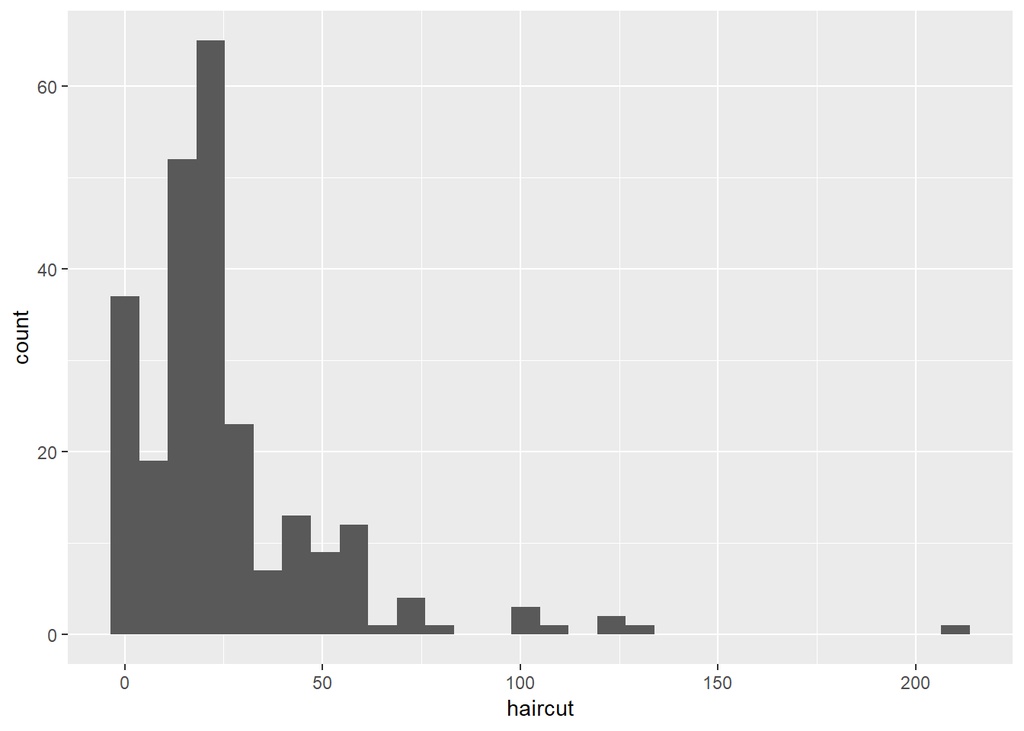

```r
ggplot(data = day1, aes(x = haircut)) +
    geom_histogram()
```

## Improvements

1. We’ll filter the rows of the `day1` tibble to include only those subjects who gave us a haircut price.

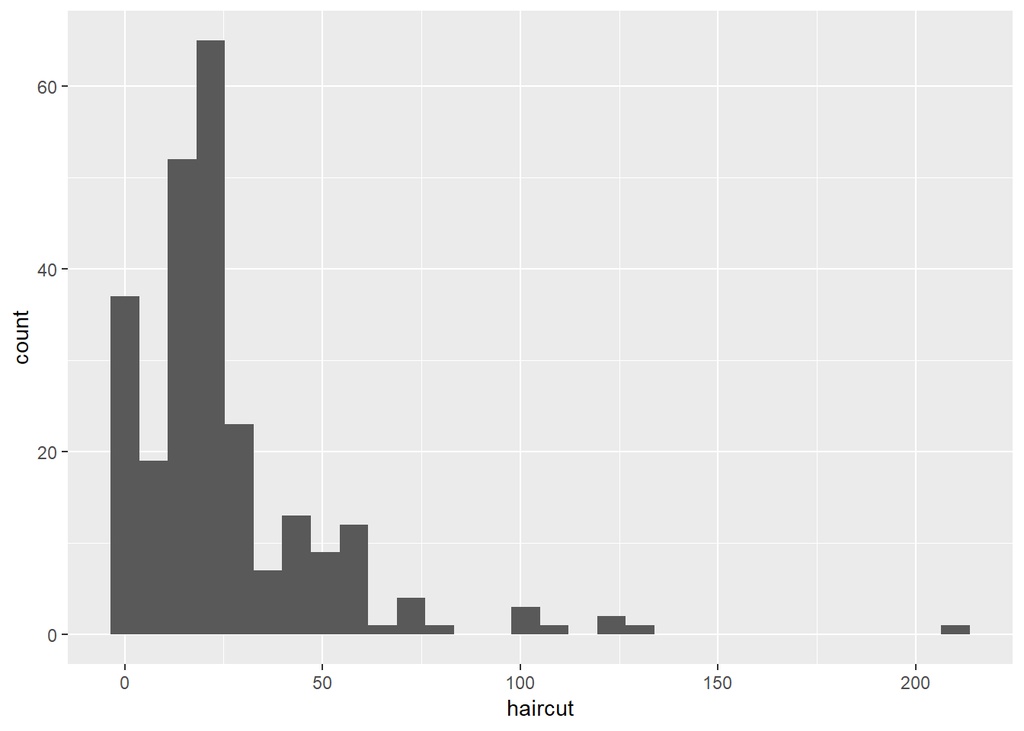

```r
day1 %>%
    filter(complete.cases(haircut)) %>%
    ggplot(data = ., aes(x = haircut)) +
    geom_histogram()
```

2. We’ll specify that R should create bins of width $10 (rather than the default, which creates 30 bins) for the haircut prices to fall in.

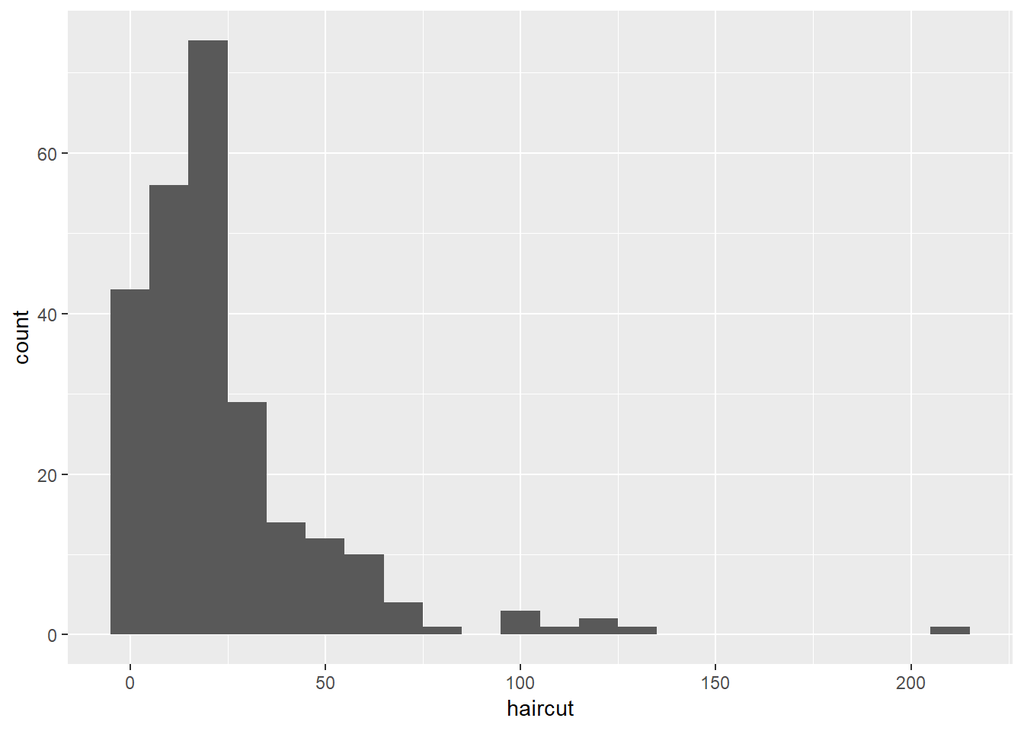

```r
day1 %>%
    filter(complete.cases(haircut)) %>%
    ggplot(data = ., aes(x = haircut)) +
    geom_histogram(binwidth = 10)
```

3. We’ll set the fill to be a better color - a nice resource for this is to google **Colors in R**. I’ll pick “slateblue”. We’ll also color the outlines of the bars “white”.

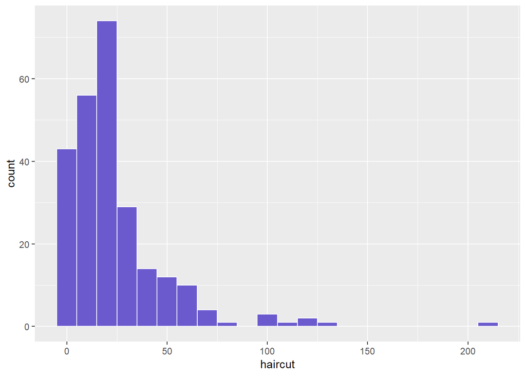

```r
day1 %>%
    filter(complete.cases(haircut)) %>%
    ggplot(data = ., aes(x = haircut)) +
    geom_histogram(binwidth = 10,
                   fill = "slateblue", col = "white")
```

4. We’ll build a main title, subtitle and proper axis titles.

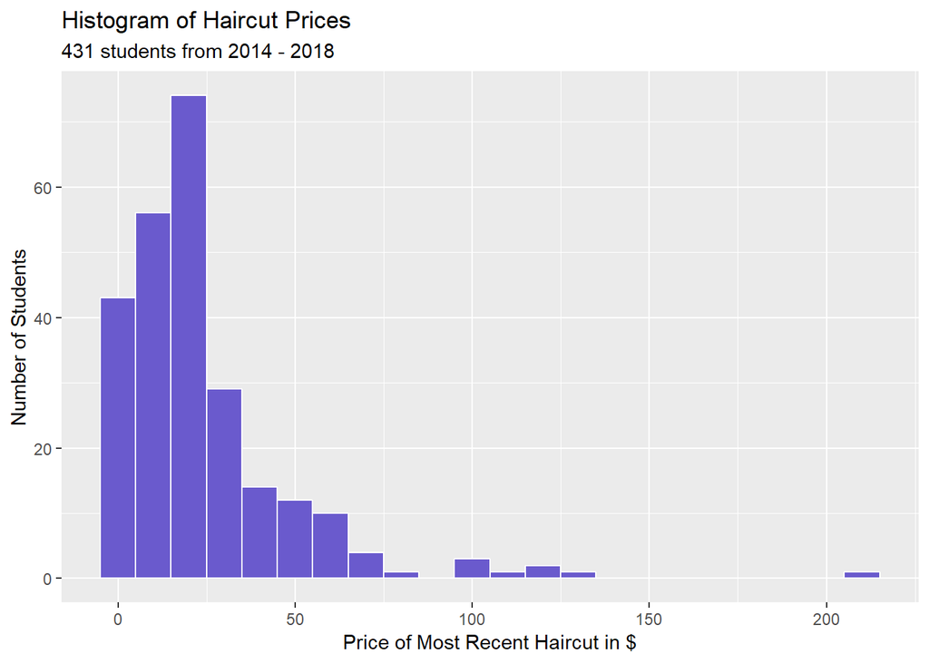

```r
day1 %>%
    filter(complete.cases(haircut)) %>%
    ggplot(data = ., aes(x = haircut)) +
    geom_histogram(binwidth = 10,
                   fill = "slateblue", col = "white") +
    labs(x = "Price of Most Recent Haircut in $",
         y = "Number of Students",
         title = "Histogram of Haircut Prices",
         subtitle = "431 students from 2014 - 2018")
```

## Separate histograms for each year with faceting?

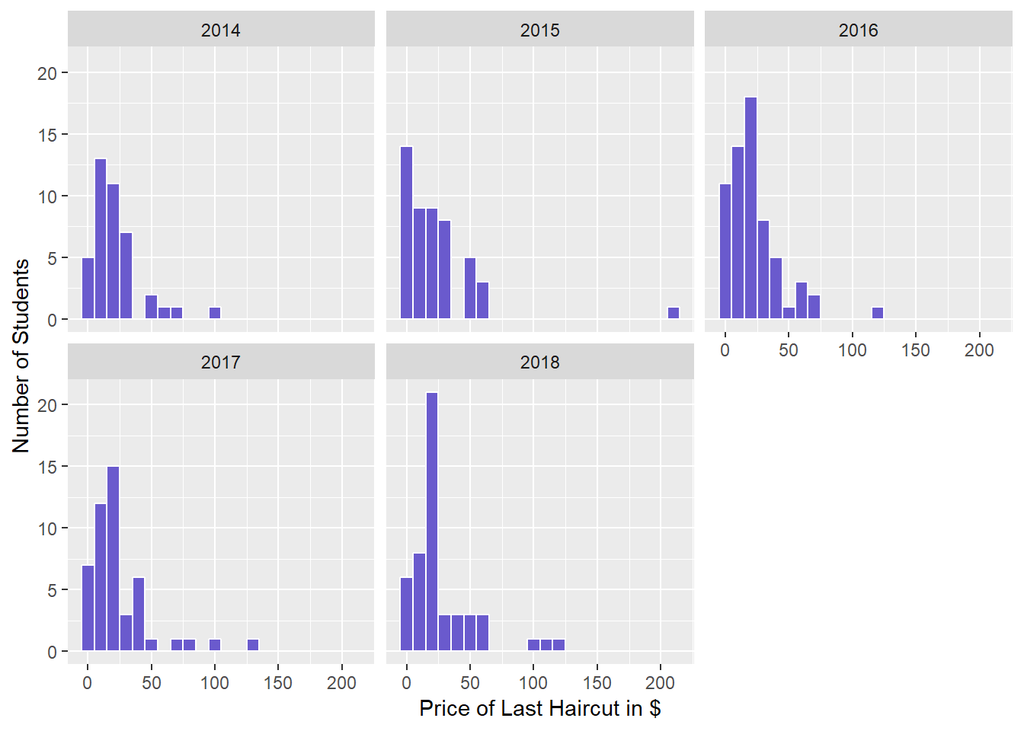

```r
day1 %>%
    filter(!is.na(haircut)) %>%
    ggplot(., aes(x = haircut)) +
        geom_histogram(binwidth = 10,
                       fill = "slateblue", color = "white") +
        guides(fill = FALSE) +
        labs(x = "Price of Last Haircut in $",
                 y = "Number of Students") +
        facet_wrap(~ year)
```

## Building a Comparison Boxplot

We could use a comparison boxplot. A trick here is to specify `year` as a factor…

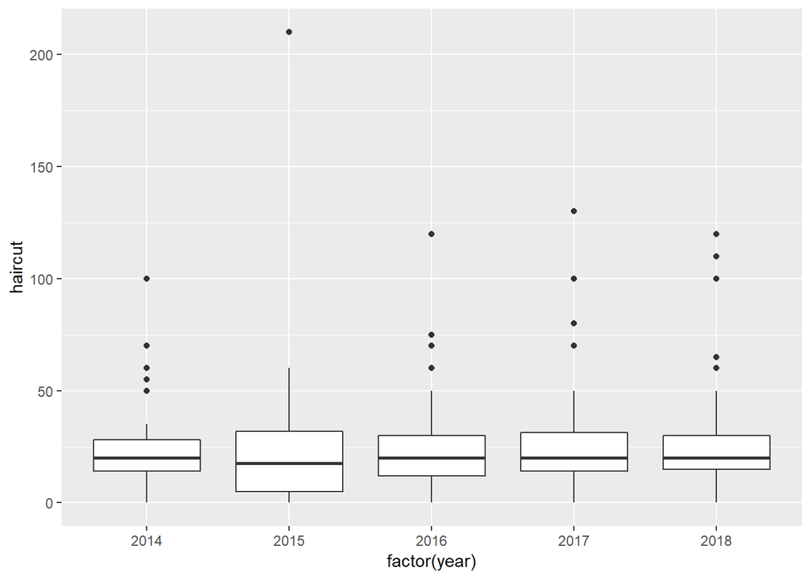

```r
day1 %>%
    filter(complete.cases(haircut)) %>%
    ggplot(data = .,
           aes(x = factor(year), y = haircut)) +
    geom_boxplot()
```

# Numerical Summaries

## Detailed Numerical Summary of Haircut Prices

```r
day1 %>%
    select(haircut) %>%
    summary()
```

```
    haircut
 Min.   :  0.00
 1st Qu.: 12.00
 Median : 20.00
 Mean   : 25.28
 3rd Qu.: 30.00
 Max.   :210.00
 NA's   :3
```

which can also be done with

```r
summary(day1$haircut)
```

```
   Min. 1st Qu.  Median    Mean 3rd Qu.    Max.    NA's
   0.00   12.00   20.00   25.28   30.00  210.00       3
```

The `mosaic` package has a useful `favstats` function…

```r
mosaic::favstats(day1$haircut)
```

```
 min Q1 median Q3 max     mean       sd   n missing
   0 12     20 30 210 25.28486 25.30809 251       3
```

But to get this in a pipeline, you’d need the `%$%` operator from the `magrittr` package…

```r
day1 %$%
    mosaic::favstats(haircut)
```

```
 min Q1 median Q3 max     mean       sd   n missing
   0 12     20 30 210 25.28486 25.30809 251       3
```

The `psych` package has a useful `describe` function…

```r
day1 %$%
    psych::describe(haircut)
```

```
   vars   n  mean    sd median trimmed   mad min max range skew
X1    1 251 25.28 25.31     20   21.28 14.83   0 210   210 2.83
   kurtosis  se
X1    13.09 1.6
```

The `Hmisc` package also has a useful `describe` function…

```r
day1 %$%
    Hmisc::describe(haircut)
```

```
haircut
       n  missing distinct     Info     Mean      Gmd      .05
     251        3       44    0.991    25.28    23.61      0.0
     .10      .25      .50      .75      .90      .95
     0.0     12.0     20.0     30.0     55.0     67.5

lowest :   0   3   5   6   7, highest: 100 110 120 130 210
```

## Numerical Summary by Year?

```r
day1 %>%
    filter(!is.na(haircut)) %>%
    group_by(year) %>%
    summarize(n = n(), mean = mean(haircut),
              sd = sd(haircut), median = median(haircut))
```

```
# A tibble: 5 x 5
   year     n  mean    sd median
  <int> <int> <dbl> <dbl>  <dbl>
1  2014    41  23.7  19.8   20
2  2015    49  24.7  32.8   17.5
3  2016    63  23.8  21.5   20
4  2017    48  25.9  25.3   20
5  2018    50  28.3  26.1   20
```

# Using `ggplot` scatterplots

## What is the relationship between 431 students’ pulse rate and hours of sleep the prior night?

Here, we’re looking at two quantitative variables. A scatterplot is usually the best choice.

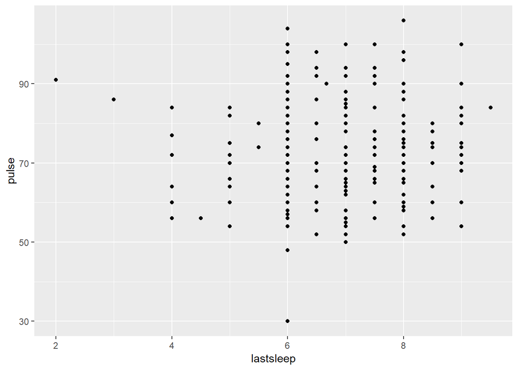

```r
ggplot(data = day1, aes(x = lastsleep, y = pulse)) +
    geom_point()
```

## Improving the Scatterplot

Let’s filter to include only those cases with known `pulse` and known `lastsleep`, and also add a line from a linear regression model to predict pulse rate on the basis of hours of sleep the prior night.

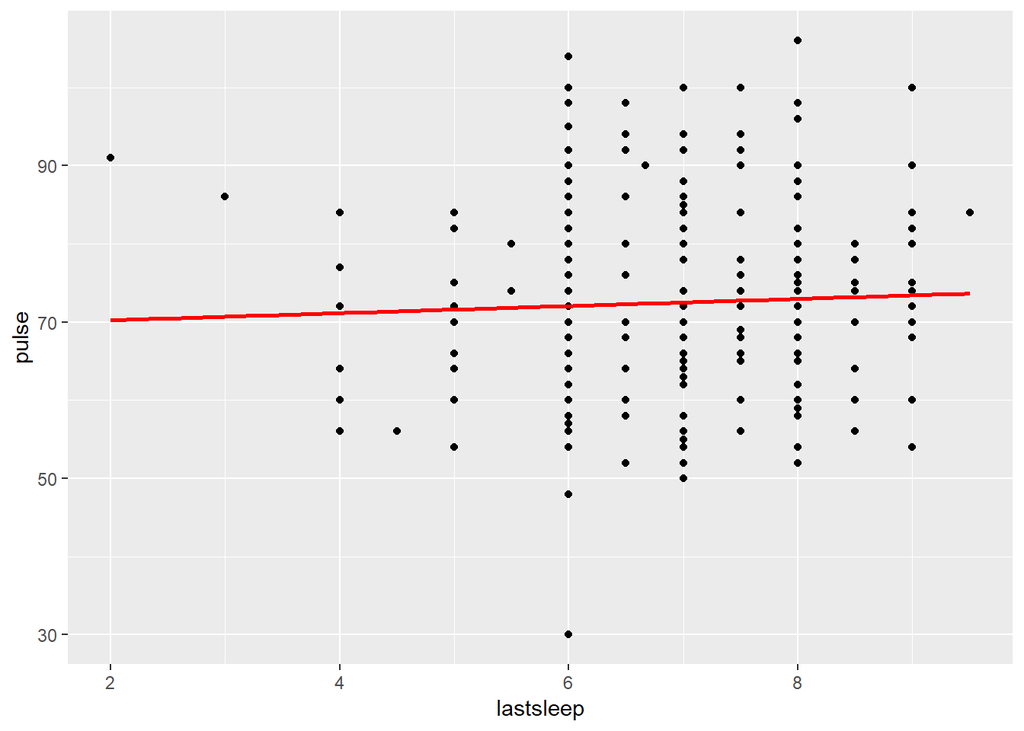

```r
day1 %>%
    filter(complete.cases(pulse, lastsleep)) %>%
    ggplot(data = ., aes(x = lastsleep, y = pulse)) +
    geom_point() +
    geom_smooth(method = "lm", se = FALSE, col = "red")
```

Let’s look at the 2018 data only, and fit a curved (loess) smooth to predict pulse rate on the basis of hours of sleep the prior night. We’ll also add a title and subtitle and retitle the axes

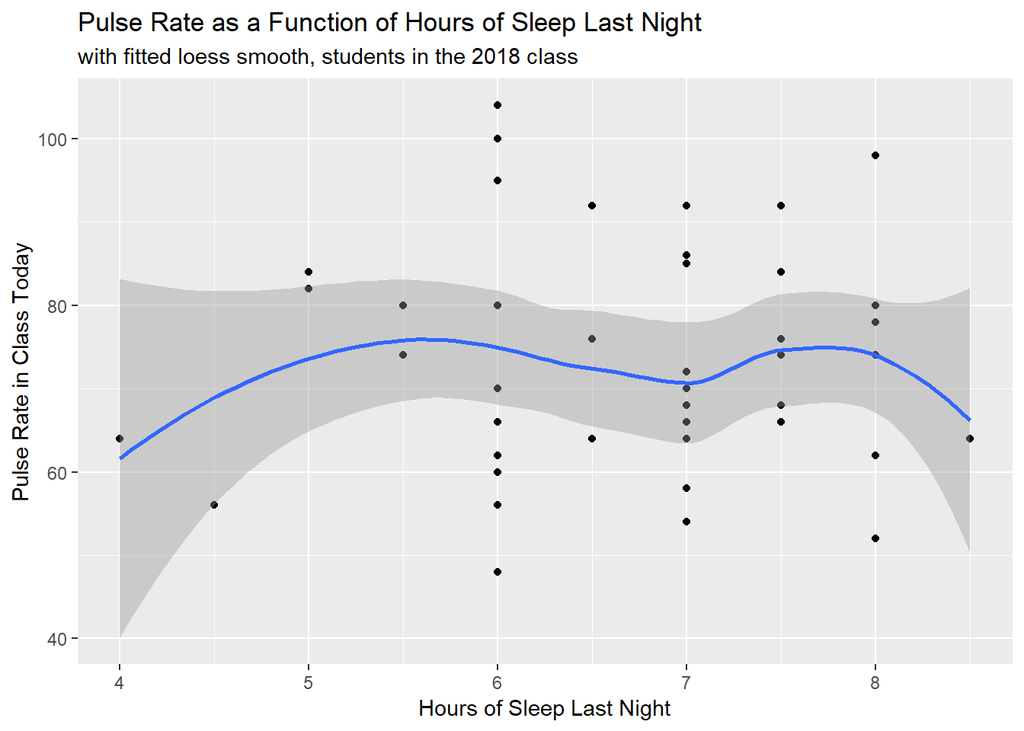

```r
day1 %>%
    filter(year == "2018") %>%
    filter(complete.cases(pulse, lastsleep)) %>%
    ggplot(data = ., aes(x = lastsleep, y = pulse)) +
    geom_point() +
    geom_smooth(method = "loess") +
    labs(title = "Pulse Rate as a Function of Hours of Sleep Last Night",
         subtitle = "with fitted loess smooth, students in the 2018 class",
         x = "Hours of Sleep Last Night",
         y = "Pulse Rate in Class Today")
```

We could instead restrict ourselves to a linear model for the 2018 group.

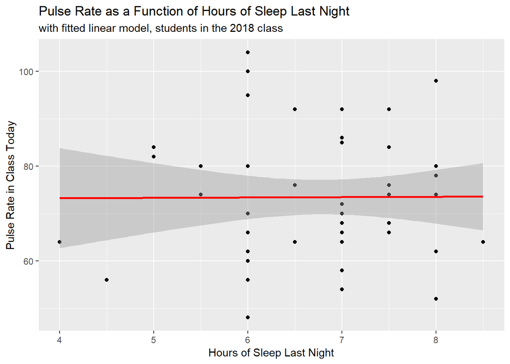

```r
day1 %>%
    filter(year == "2018") %>%
    filter(complete.cases(pulse, lastsleep)) %>%
    ggplot(data = ., aes(x = lastsleep, y = pulse)) +
    geom_point() +
    geom_smooth(method = "lm", col = "red") +
    labs(title = "Pulse Rate as a Function of Hours of Sleep Last Night",
         subtitle = "with fitted linear model, students in the 2018 class",
         x = "Hours of Sleep Last Night",
         y = "Pulse Rate in Class Today")
```

The correlation of `lastsleep` and `pulse` is likely to be of some interest. Note the use of both the `%>%` and `%$%` pipes in this case.

```r
day1 %>%
    filter(year == "2018") %>%
    filter(complete.cases(pulse, lastsleep)) %$%
    cor(pulse, lastsleep)
```

```
[1] 0.006008713
```

## Does the linear model change much by year?

Here’s the plot, color coding the models by year (note the use of the group as well as the color aesthetic here), and also incorporating the black-and-white theme, rather than the default.

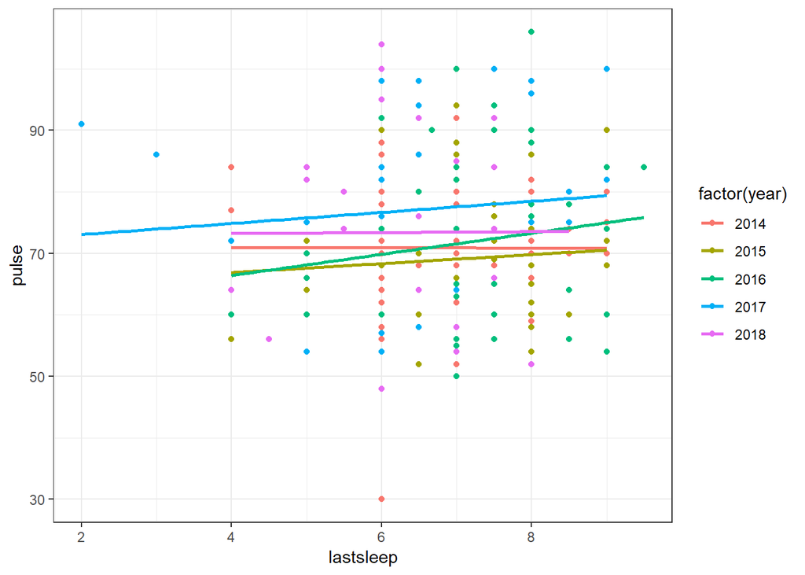

```r
day1 %>%
    filter(complete.cases(pulse, lastsleep)) %>%
    ggplot(., aes(x = lastsleep, y = pulse,
                                color = factor(year),
                                group = factor(year))) +
    geom_point() +
    geom_smooth(method = "lm", se = FALSE) +
      theme_bw()
```

Here’s the same plot of the models alone, and not showing the data (commenting out the line of code that draws the points.) We’ll also improve the labeling.

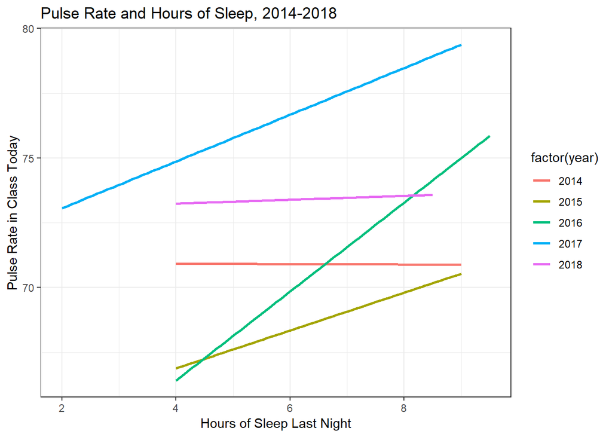

```r
day1 %>%
    filter(complete.cases(pulse, lastsleep)) %>%
    ggplot(., aes(x = lastsleep, y = pulse,
                                color = factor(year),
                                group = factor(year))) +
 #   geom_point() +
    geom_smooth(method = "lm", se = FALSE) +
    labs(title = "Pulse Rate and Hours of Sleep, 2014-2018",
         x = "Hours of Sleep Last Night",
         y = "Pulse Rate in Class Today") +
      theme_bw()
```

## Faceting a Scatterplot

Here’s the same basic information, but faceted by year.

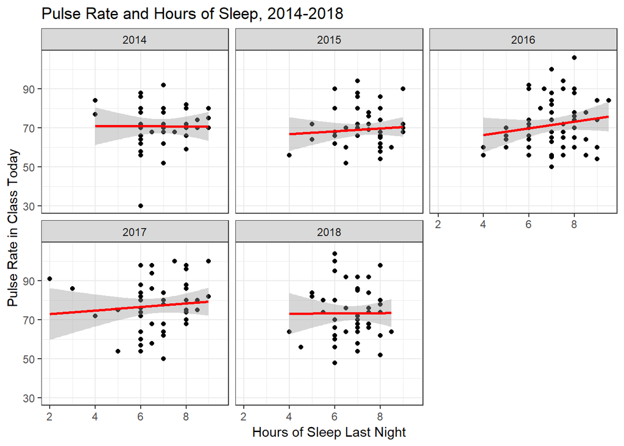

```r
day1 %>%
    filter(complete.cases(pulse, lastsleep)) %>%
    ggplot(data = ., aes(x = lastsleep, y = pulse,
                                group = factor(year))) +
    geom_point() +
    geom_smooth(method = "lm", color = "red") +
    facet_wrap(~ year) +
    labs(title = "Pulse Rate and Hours of Sleep, 2014-2018",
         x = "Hours of Sleep Last Night",
         y = "Pulse Rate in Class Today") +
    theme_bw()
```